# The Maternal Health Gap: A 20-Year Story (2000–2020)

Author

Hiraldo Egidius Hogeputra | Student Number: A00054649

```python
# Descriptive stats reviewed to catch outliers before visualisation
print("=== Indicator1 summary ===")
print(indicator1.describe())

# Only relevant metadata columns selected to keep the summary focused
print("\n=== Metadata summary ===")
print(
    metadata.select([
        "year",
        "GDP per capita (constant 2015 US$)",
        "Life expectancy at birth, total (years)",
        "Population, total"
    ]).describe()
)

# Country coverage compared — large mismatch would reduce join output
print(f"\nUnique countries in indicator1: {indicator1['country'].n_unique()}")
print(f"Unique countries in metadata:   {metadata['country'].n_unique()}")
```

```
=== Indicator1 summary ===
shape: (9, 15)
┌───────────┬───────────┬───────────┬───────────┬───┬───────────┬───────────┬───────────┬──────────┐
│ statistic ┆ country   ┆ alpha_2_c ┆ alpha_3_c ┆ … ┆ observati ┆ observati ┆ time_peri ┆ current_ │
│ ---       ┆ ---       ┆ ode       ┆ ode       ┆   ┆ on_status ┆ on_confid ┆ od_activi ┆ age      │
│ str       ┆ str       ┆ ---       ┆ ---       ┆   ┆ ---       ┆ entaility ┆ ty_relate ┆ ---      │
│           ┆           ┆ str       ┆ str       ┆   ┆ str       ┆ ---       ┆ d_t…      ┆ str      │
│           ┆           ┆           ┆           ┆   ┆           ┆ str       ┆ ---       ┆          │
│           ┆           ┆           ┆           ┆   ┆           ┆           ┆ str       ┆          │
╞═══════════╪═══════════╪═══════════╪═══════════╪═══╪═══════════╪═══════════╪═══════════╪══════════╡
│ count     ┆ 3885      ┆ 3864      ┆ 3885      ┆ … ┆ 3885      ┆ 3885      ┆ 0         ┆ 3885     │
│ null_coun ┆ 0         ┆ 21        ┆ 0         ┆ … ┆ 0         ┆ 0         ┆ 3885      ┆ 0        │
│ t         ┆           ┆           ┆           ┆   ┆           ┆           ┆           ┆          │
│ mean      ┆ null      ┆ null      ┆ null      ┆ … ┆ null      ┆ null      ┆ null      ┆ null     │
│ std       ┆ null      ┆ null      ┆ null      ┆ … ┆ null      ┆ null      ┆ null      ┆ null     │
│ min       ┆ Afghanist ┆ AE        ┆ AFG       ┆ … ┆ Modelled  ┆ Free      ┆ null      ┆ Total    │
│           ┆ an        ┆           ┆           ┆   ┆           ┆           ┆           ┆          │
│ 25%       ┆ null      ┆ null      ┆ null      ┆ … ┆ null      ┆ null      ┆ null      ┆ null     │
│ 50%       ┆ null      ┆ null      ┆ null      ┆ … ┆ null      ┆ null      ┆ null      ┆ null     │
│ 75%       ┆ null      ┆ null      ┆ null      ┆ … ┆ null      ┆ null      ┆ null      ┆ null     │
│ max       ┆ Zimbabwe  ┆ ZW        ┆ ZWE       ┆ … ┆ Modelled  ┆ Free      ┆ null      ┆ Total    │
└───────────┴───────────┴───────────┴───────────┴───┴───────────┴───────────┴───────────┴──────────┘

=== Metadata summary ===
shape: (9, 5)
┌────────────┬───────────┬────────────────────────────────┬────────────────────┬───────────────────┐
│ statistic  ┆ year      ┆ GDP per capita (constant 2015  ┆ Life expectancy at ┆ Population, total │
│ ---        ┆ ---       ┆ …                              ┆ birth, tota…       ┆ ---               │
│ str        ┆ f64       ┆ ---                            ┆ ---                ┆ f64               │
│            ┆           ┆ f64                            ┆ f64                ┆                   │
╞════════════╪═══════════╪════════════════════════════════╪════════════════════╪═══════════════════╡
│ count      ┆ 13715.0   ┆ 11221.0                        ┆ 13470.0            ┆ 13685.0           │
│ null_count ┆ 0.0       ┆ 2494.0                         ┆ 245.0              ┆ 30.0              │
│ mean       ┆ 1992.0    ┆ 12430.305512                   ┆ 65.099933          ┆ 2.6015e7          │
│ std        ┆ 18.762347 ┆ 19493.096157                   ┆ 11.288181          ┆ 1.0707e8          │
│ min        ┆ 1960.0    ┆ 122.678901                     ┆ 10.989             ┆ 4607.0            │
│ 25%        ┆ 1976.0    ┆ 1340.997021                    ┆ 58.319             ┆ 573586.0          │
│ 50%        ┆ 1992.0    ┆ 3986.997779                    ┆ 67.711             ┆ 4.515453e6        │
│ 75%        ┆ 2008.0    ┆ 15922.638665                   ┆ 73.31878           ┆ 1.4771147e7       │
│ max        ┆ 2024.0    ┆ 247170.219911                  ┆ 86.372             ┆ 1.4509e9          │
└────────────┴───────────┴────────────────────────────────┴────────────────────┴───────────────────┘

Unique countries in indicator1: 185
Unique countries in metadata:   211
```

```python
# Year column in metadata renamed to match indicator1's 'time_period' key
metadata_clean = metadata.rename({"year": "time_period"})

# Inner join applied — only rows with complete data on both sides retained,
# as incomplete records would undermine the scatterplot and map accuracy
data_joined = indicator1.join(
    metadata_clean,
    on=["country", "time_period"],
    how="inner"
)

# Sorted by year for consistent ordering in time-series visualisation
data_final = data_joined.sort("time_period")

# Row count checked post-join — unexpected losses may signal country name mismatches
print(f"Rows after join:   {data_final.shape[0]}")
print(f"Rows lost in join: {indicator1.shape[0] - data_final.shape[0]}")
print(data_final.head(5))
```

```
Rows after join:   3864
Rows lost in join: 21
shape: (5, 27)
┌───────────┬───────────┬───────────┬───────────┬───┬───────────┬───────────┬───────────┬──────────┐
│ country   ┆ alpha_2_c ┆ alpha_3_c ┆ numeric_c ┆ … ┆ Fossil    ┆ GDP       ┆ Birth     ┆ Hospital │
│ ---       ┆ ode       ┆ ode       ┆ ode       ┆   ┆ fuel      ┆ growth    ┆ rate,     ┆ beds     │
│ str       ┆ ---       ┆ ---       ┆ ---       ┆   ┆ energy    ┆ (annual   ┆ crude     ┆ (per     │
│           ┆ str       ┆ str       ┆ i64       ┆   ┆ consumpti ┆ %)        ┆ (per      ┆ 1,000    │
│           ┆           ┆           ┆           ┆   ┆ on…       ┆ ---       ┆ 1,000 p…  ┆ peopl…   │
│           ┆           ┆           ┆           ┆   ┆ ---       ┆ f64       ┆ ---       ┆ ---      │
│           ┆           ┆           ┆           ┆   ┆ f64       ┆           ┆ f64       ┆ f64      │
╞═══════════╪═══════════╪═══════════╪═══════════╪═══╪═══════════╪═══════════╪═══════════╪══════════╡
│ Afghanist ┆ AF        ┆ AFG       ┆ 4         ┆ … ┆ null      ┆ null      ┆ 51.491    ┆ null     │
│ an        ┆           ┆           ┆           ┆   ┆           ┆           ┆           ┆          │
│ Albania   ┆ AL        ┆ ALB       ┆ 8         ┆ … ┆ 58.626225 ┆ 7.462859  ┆ 17.513    ┆ 3.21     │
│ Algeria   ┆ DZ        ┆ DZA       ┆ 12        ┆ … ┆ 99.79733  ┆ 3.8       ┆ 19.574    ┆ 1.77     │
│ Angola    ┆ AO        ┆ AGO       ┆ 24        ┆ … ┆ 26.14821  ┆ 3.054624  ┆ 46.853    ┆ null     │
│ Antigua   ┆ AG        ┆ ATG       ┆ 28        ┆ … ┆ null      ┆ 6.203552  ┆ 19.72     ┆ null     │
│ and       ┆           ┆           ┆           ┆   ┆           ┆           ┆           ┆          │
│ Barbuda   ┆           ┆           ┆           ┆   ┆           ┆           ┆           ┆          │
└───────────┴───────────┴───────────┴───────────┴───┴───────────┴───────────┴───────────┴──────────┘
```

```python
# Total and average maternal deaths aggregated per country —
# results feed directly into the bar chart and world map
deaths_by_country = (
    data_final
    .group_by("country")
    .agg([
        pl.col("obs_value").sum().alias("total_deaths"),
        pl.col("obs_value").mean().alias("avg_annual_deaths"),
        pl.col("time_period").count().alias("years_reported")
    ])
    .sort("total_deaths", descending=True)
)

# avg_annual_deaths included to fairly compare countries regardless of reporting gaps
print("Top 10 countries by total maternal deaths (2000–2020):")
print(deaths_by_country.head(10))
```

```
Top 10 countries by total maternal deaths (2000–2020):
shape: (10, 4)
┌─────────────────────────────────┬──────────────┬───────────────────┬────────────────┐
│ country                         ┆ total_deaths ┆ avg_annual_deaths ┆ years_reported │
│ ---                             ┆ ---          ┆ ---               ┆ ---            │
│ str                             ┆ f64          ┆ f64               ┆ u32            │
╞═════════════════════════════════╪══════════════╪═══════════════════╪════════════════╡
│ Nigeria                         ┆ 1.546984e6   ┆ 73665.904762      ┆ 21             │
│ India                           ┆ 1187605.2    ┆ 56552.628571      ┆ 21             │
│ Ethiopia                        ┆ 429580.8     ┆ 20456.228571      ┆ 21             │
│ Congo, the Democratic Republic… ┆ 374949.1     ┆ 17854.719048      ┆ 21             │
│ Pakistan                        ┆ 314828.3     ┆ 14991.82381       ┆ 21             │
│ Indonesia                       ┆ 231353.4     ┆ 11016.828571      ┆ 21             │
│ Afghanistan                     ┆ 226541.4     ┆ 10787.685714      ┆ 21             │
│ Bangladesh                      ┆ 210923.1     ┆ 10043.957143      ┆ 21             │
│ Tanzania, United Republic of    ┆ 174269.2     ┆ 8298.533333       ┆ 21             │
│ Kenya                           ┆ 149407.9     ┆ 7114.661905       ┆ 21             │
└─────────────────────────────────┴──────────────┴───────────────────┴────────────────┘
```

## 🌍 The Global Picture

### Maternal Deaths Mapped Across the World (2000–2020)

The map below plots the average annual number of maternal deaths by country across the full 20-year period. The colour gradient runs from **light** (few deaths) to **deep red** (highest burden) making the geographic concentration of risk immediately visible.

Two patterns stand out: **sub-Saharan Africa** and **South Asia** consistently dominate the darker shades, while Europe, North America, and East Asia remain near-invisible on the scale. This is not merely a story of population size it reflects profound disparities in access to skilled birth attendants, emergency obstetric care, and basic health infrastructure.

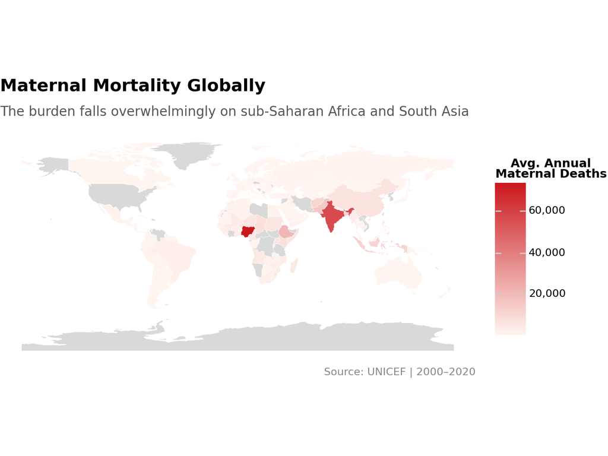

Figure 1: Average annual maternal deaths by country (2000–2020). Deep red indicates the highest burden; grey denotes no data available. Sub-Saharan Africa and South Asia dominate the darker shades throughout the period.

```python
map_plot = (
    ggplot(world_merged)
    + geom_map(aes(fill="avg_maternal_deaths"), color="white", size=0.1)
    + scale_fill_gradient(
        low="#fff5f0",
        high="#cb181d",
        na_value="#d9d9d9",
        name="Avg. Annual\nMaternal Deaths",
        labels=label_comma()
    )
    + coord_fixed()
    + theme_void()
    + theme(
        plot_title=element_text(size=13, weight="bold", margin={"b": 8}),
        plot_subtitle=element_text(size=10, color="#555555", margin={"b": 10}),
        plot_caption=element_text(size=8, color="#888888"),
        legend_title=element_text(size=9, weight="bold"),
        legend_text=element_text(size=8),
        plot_background=element_rect(fill="white"),
    )
    + labs(
        title="Maternal Mortality Globally",
        subtitle="The burden falls overwhelmingly on sub-Saharan Africa and South Asia",
        caption="Source: UNICEF | 2000–2020"
    )
)

map_plot
```

## 💰 Does Wealth Equal Health?

The intuitive assumption is that richer countries are simply safer for mothers. The chart below puts that assumption to the test plotting **GDP per capita** against **maternal deaths** for every country-year observation in the dataset. Dot size also encodes GDP, making the contrast between wealthy and poor nations immediately visible.

The negative correlation is real: as national income rises, maternal deaths tend to fall. Yet a striking cluster of **lower-income countries sits near the bottom of the scale** nations achieving low maternal mortality despite modest GDPs. They do so by investing smartly in the basics: trained midwives, rural clinic access, and emergency transport rather than expensive hospital infrastructure.

These *“Rule Breakers”* demonstrate that **targeted policy can outperform raw economic power**. Conversely, several middle-income countries sit well above the regression line a reminder that wealth alone does not guarantee equitable healthcare delivery.

> *The regression line below is not a ceiling, it is a challenge.* Countries above it have room to close the gap without waiting for economic growth.

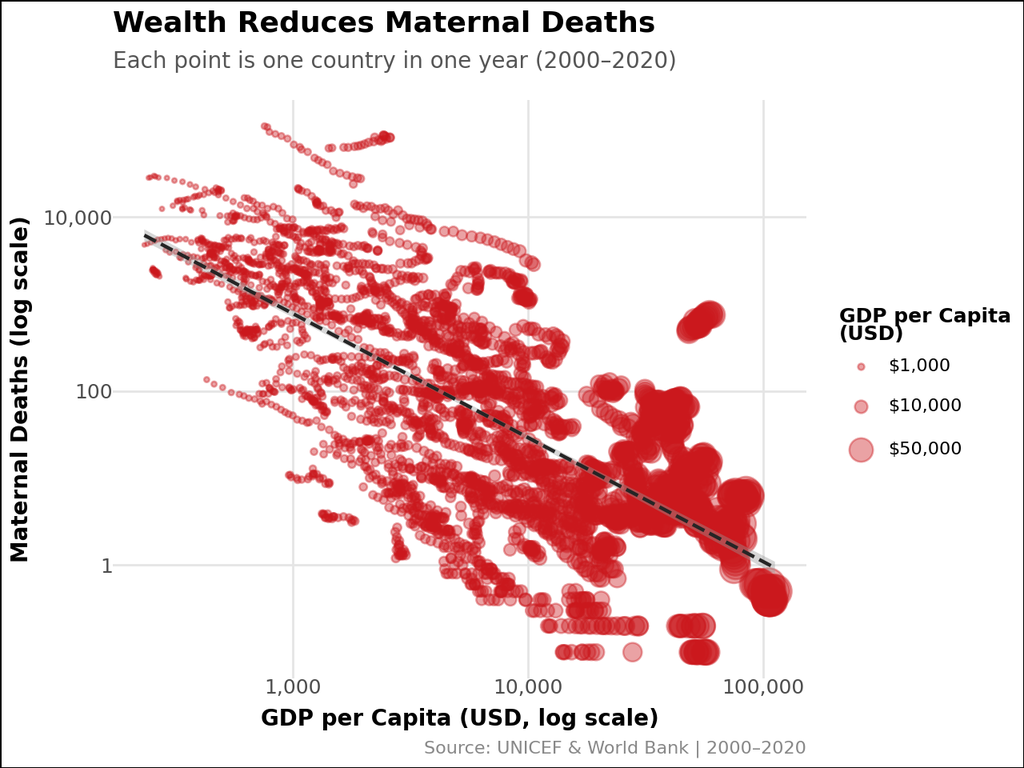

Figure 2: GDP per capita (USD) vs. maternal deaths per country-year. Dot size represents GDP, larger dots are wealthier nations clustering toward fewer deaths. The dashed regression line confirms the negative relationship.

```python
scatter_data = (
    data_final
    .select([
        "country",
        "time_period",
        "obs_value",
        "GDP per capita (constant 2015 US$)"
    ])
    .rename({"GDP per capita (constant 2015 US$)": "gdp_per_capita"})
    .drop_nulls()
    .filter(
        (pl.col("obs_value") > 0) &
        (pl.col("gdp_per_capita") > 0)
    )
    .to_pandas()
)

scatter_plot = (
    ggplot(scatter_data, aes(x="gdp_per_capita", y="obs_value"))
    + geom_point(aes(size="gdp_per_capita"), color="#cb181d", alpha=0.4)
    + geom_smooth(method="lm", color="#252525", size=0.9, linetype="dashed")
    + scale_x_log10(labels=label_comma())
    + scale_y_log10(labels=label_comma())
    + scale_size_continuous(
        range=(0.5, 8),
        name="GDP per Capita\n(USD)",
        breaks=[1000, 10000, 50000],
        labels=["$1,000", "$10,000", "$50,000"]
    )
    + theme_minimal()
    + theme(
        plot_title=element_text(size=13, weight="bold", margin={"b": 6}),
        plot_subtitle=element_text(size=10, color="#555555", margin={"b": 12}),
        axis_title=element_text(size=10, weight="bold"),
        axis_text=element_text(size=9),
        panel_grid_minor=element_blank(),
        plot_caption=element_text(size=8, color="#888888"),
        plot_background=element_rect(fill="white"),
        legend_title=element_text(size=9, weight="bold"),
        legend_text=element_text(size=8),
    )
    + labs(
        title="Wealth Reduces Maternal Deaths",
        subtitle="Each point is one country in one year (2000–2020)",
        x="GDP per Capita (USD, log scale)",
        y="Maternal Deaths (log scale)",
        caption="Source: UNICEF & World Bank | 2000–2020"
    )
)

scatter_plot
```

## 🎯 Where Can We Make the Biggest Impact?

Global averages mask the urgency of country-specific crises. To allocate resources effectively, it matters **which nations carry the highest absolute burden** of maternal deaths, not just which regions trend poorly.

The chart below ranks the **top 10 countries by total maternal deaths** recorded across the full 20-year period. **Nigeria and India** consistently lead, though for different reasons. Nigeria’s figures reflect a severe shortage of skilled birth attendants and emergency obstetric infrastructure. India’s high absolute count is partly explained by population scale, yet its maternal mortality ratio has declined substantially since 2000, signalling meaningful policy progress.

- Countries near the **top of the list with flat trends** require urgent international intervention
- Countries **falling fast** in the ranking are models worth studying
- **Democratic Republic of Congo, Pakistan and Ethiopia** each represent contexts where targeted funding could yield rapid results

> The data does not just identify problems, it points to where **the next saved life is most achievable**.

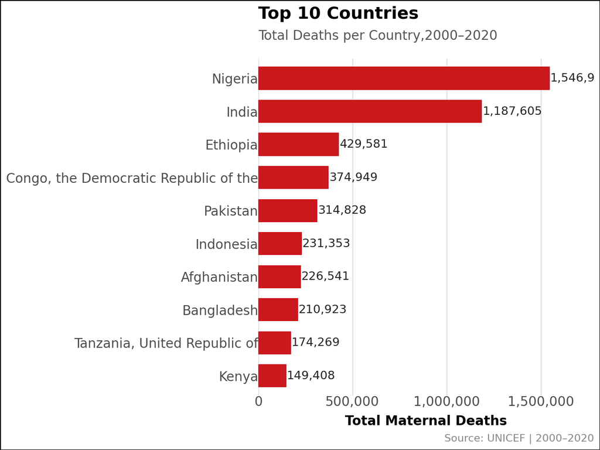

Figure 3: Top 10 countries by total maternal deaths recorded between 2000 and 2020. Nigeria and India account for a disproportionate share of the global burden, though for contrasting reasons of infrastructure deficit and population scale respectively.

```python
bar_plot = (
    ggplot(bar_data, aes(x="country", y="total_deaths"))
    + geom_bar(stat="identity", fill="#cb181d", width=0.7)
    + geom_text(
        aes(label="total_deaths"),
        format_string="{:,.0f}",
        ha="left",
        size=9,
        nudge_y=2000,
        color="#252525"
    )
    + coord_flip()
    + scale_y_continuous(
        labels=label_comma(),
        expand=(0, 0, 0.15, 0)
    )
    + theme_minimal()
    + theme(
        plot_title=element_text(size=13, weight="bold", margin={"b": 6}),
        plot_subtitle=element_text(size=10, color="#555555", margin={"b": 12}),
        axis_title_y=element_blank(),
        axis_title_x=element_text(size=10, weight="bold"),
        axis_text=element_text(size=10),
        panel_grid_major_y=element_blank(),
        panel_grid_minor=element_blank(),
        plot_caption=element_text(size=8, color="#888888"),
        plot_background=element_rect(fill="white"),
    )
    + labs(
        title="Top 10 Countries",
        subtitle="Total Deaths per Country,2000–2020",
        x=None,
        y="Total Maternal Deaths",
        caption="Source: UNICEF | 2000–2020"
    )
)

bar_plot
```

## 📈 The Big Picture: Are We Winning?

Before examining individual countries, it is worth stepping back to ask the most fundamental question: **is the world actually making progress?**

- **The rate of decline has slowed**: since approximately 2015, coinciding with reduced international aid commitments and disruption caused by conflict in high-burden regions
- **The absolute number remains unacceptably high**: nearly 800 women still die every single day from preventable causes related to childbirth
- **Progress has been uneven**: while some nations have cut their rates by more than 70%, others have seen figures stagnate or worsen

> A falling global line is cause for cautious optimism, **not complacency**. The challenge now is to accelerate progress in the countries that have been left behind.

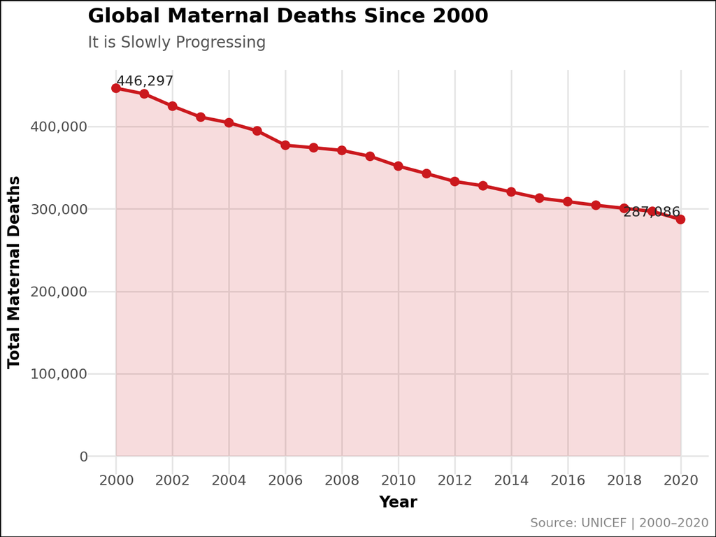

```python
timeseries_plot = (
    ggplot(timeseries_data, aes(x="time_period", y="global_deaths"))
    + geom_area(fill="#cb181d", alpha=0.15)
    + geom_line(color="#cb181d", size=1.2)
    + geom_point(color="#cb181d", size=2.5)
    + annotate(
        "text",
        x=int(start_yr),
        y=float(start_val),
        label=f"{int(start_val):,}",
        va="bottom",
        ha="left",
        size=9,
        color="#252525"
    )
    + annotate(
        "text",
        x=int(end_yr),
        y=float(end_val),
        label=f"{int(end_val):,}",
        va="bottom",
        ha="right",
        size=9,
        color="#252525"
    )
    + scale_x_continuous(breaks=list(range(2000, 2021, 2)))
    + scale_y_continuous(labels=label_comma(), limits=(0, None))
    + theme_minimal()
    + theme(
        plot_title=element_text(size=13, weight="bold", margin={"b": 6}),
        plot_subtitle=element_text(size=10, color="#555555", margin={"b": 12}),
        axis_title=element_text(size=10, weight="bold"),
        axis_text=element_text(size=9),
        panel_grid_minor=element_blank(),
        plot_caption=element_text(size=8, color="#888888"),
        plot_background=element_rect(fill="white"),
    )
    + labs(
        title="Global Maternal Deaths Since 2000",
        subtitle="It is Slowly Progressing",
        x="Year",
        y="Total Maternal Deaths",
        caption="Source: UNICEF | 2000–2020"
    )
)

timeseries_plot
```

## 🔎 The Final Takeaway

Twenty years of data tell a story that is simultaneously hopeful and urgent. The tools, the knowledge, and the interventions needed to end preventable maternal death **already exist**, the gap is not scientific, it is a matter of political will and resource allocation.

Three evidence-based conclusions emerge from this analysis:

1. **Geography, not destiny**: the concentration of maternal deaths in sub-Saharan Africa and South Asia is not inevitable. Countries within those same regions have demonstrated dramatic improvements when given adequate support and investment.
2. **Wealth is an enabler, not a prerequisite**: the scatterplot shows clearly that low-income countries *can* achieve low maternal mortality. Smart policy, community-based care, and trained local midwives consistently outperform expensive infrastructure alone.
3. **The window for impact is narrowing**: with the rate of global decline slowing since 2015, the coming decade is critical. Without renewed urgency, the remaining burden will become entrenched.

### 📣 What Can Be Done?

The countries at the top of the bar chart are not lost causes, they are **the highest-return investment opportunities in global health**. Directing resources toward Nigeria, the Democratic Republic of Congo, and Pakistan, while learning from the *“Rule Breakers”* who have achieved safety on modest budgets, offers the clearest path to closing the maternal health gap.

> *No mother should die giving life. The data shows we can prevent it, the question is whether we choose to.*

*Data sourced from UNICEF and the World Bank